# Risk Factor Analysis

## Outcome Variable

**Outcome Variable:** stunted

## Predictor Variables

**Intervention Variable:** nrooms

**Adjustment Set:**

unadjusted

## Stratifying Variables

The analysis was stratified on these variable(s):

- agecat
- studyid
- country

## Data Summary

| agecat | studyid | country | A | n | nA | nAY0 | nAY1 |
| --- | --- | --- | --- | --- | --- | --- | --- |
| Birth | ki0047075b-MAL-ED | BANGLADESH | 1 | 234 | 144 | 116 | 28 |
| Birth | ki0047075b-MAL-ED | BANGLADESH | 2 | 234 | 50 | 42 | 8 |
| Birth | ki0047075b-MAL-ED | BANGLADESH | 3 | 234 | 28 | 26 | 2 |
| Birth | ki0047075b-MAL-ED | BANGLADESH | 4+ | 234 | 12 | 12 | 0 |
| Birth | ki0047075b-MAL-ED | BRAZIL | 1 | 174 | 3 | 3 | 0 |
| Birth | ki0047075b-MAL-ED | BRAZIL | 2 | 174 | 19 | 18 | 1 |
| Birth | ki0047075b-MAL-ED | BRAZIL | 3 | 174 | 50 | 43 | 7 |
| Birth | ki0047075b-MAL-ED | BRAZIL | 4+ | 174 | 102 | 93 | 9 |
| Birth | ki0047075b-MAL-ED | INDIA | 1 | 191 | 69 | 63 | 6 |
| Birth | ki0047075b-MAL-ED | INDIA | 2 | 191 | 68 | 51 | 17 |
| Birth | ki0047075b-MAL-ED | INDIA | 3 | 191 | 32 | 27 | 5 |
| Birth | ki0047075b-MAL-ED | INDIA | 4+ | 191 | 22 | 20 | 2 |
| Birth | ki0047075b-MAL-ED | NEPAL | 1 | 171 | 36 | 33 | 3 |
| Birth | ki0047075b-MAL-ED | NEPAL | 2 | 171 | 21 | 20 | 1 |
| Birth | ki0047075b-MAL-ED | NEPAL | 3 | 171 | 17 | 13 | 4 |
| Birth | ki0047075b-MAL-ED | NEPAL | 4+ | 171 | 97 | 87 | 10 |
| Birth | ki0047075b-MAL-ED | PERU | 1 | 259 | 17 | 16 | 1 |
| Birth | ki0047075b-MAL-ED | PERU | 2 | 259 | 51 | 47 | 4 |
| Birth | ki0047075b-MAL-ED | PERU | 3 | 259 | 59 | 54 | 5 |
| Birth | ki0047075b-MAL-ED | PERU | 4+ | 259 | 132 | 111 | 21 |
| Birth | ki0047075b-MAL-ED | SOUTH AFRICA | 1 | 218 | 14 | 14 | 0 |
| Birth | ki0047075b-MAL-ED | SOUTH AFRICA | 2 | 218 | 21 | 19 | 2 |
| Birth | ki0047075b-MAL-ED | SOUTH AFRICA | 3 | 218 | 23 | 21 | 2 |
| Birth | ki0047075b-MAL-ED | SOUTH AFRICA | 4+ | 218 | 160 | 142 | 18 |
| Birth | ki0047075b-MAL-ED | TANZANIA, UNITED REPUBLIC OF | 1 | 118 | 6 | 6 | 0 |
| Birth | ki0047075b-MAL-ED | TANZANIA, UNITED REPUBLIC OF | 2 | 118 | 24 | 19 | 5 |
| Birth | ki0047075b-MAL-ED | TANZANIA, UNITED REPUBLIC OF | 3 | 118 | 33 | 29 | 4 |
| Birth | ki0047075b-MAL-ED | TANZANIA, UNITED REPUBLIC OF | 4+ | 118 | 55 | 48 | 7 |
| Birth | ki1000108-CMC-V-BCS-2002 | INDIA | 1 | 90 | 38 | 32 | 6 |
| Birth | ki1000108-CMC-V-BCS-2002 | INDIA | 2 | 90 | 28 | 22 | 6 |

[output cut: 398 more lines]

The following strata were considered:

- agecat: 12 months, studyid: ki0047075b-MAL-ED, country: BANGLADESH
- agecat: 12 months, studyid: ki0047075b-MAL-ED, country: BRAZIL
- agecat: 12 months, studyid: ki0047075b-MAL-ED, country: INDIA
- agecat: 12 months, studyid: ki0047075b-MAL-ED, country: NEPAL
- agecat: 12 months, studyid: ki0047075b-MAL-ED, country: PERU
- agecat: 12 months, studyid: ki0047075b-MAL-ED, country: SOUTH AFRICA
- agecat: 12 months, studyid: ki0047075b-MAL-ED, country: TANZANIA, UNITED REPUBLIC OF
- agecat: 12 months, studyid: ki1000108-CMC-V-BCS-2002, country: INDIA
- agecat: 12 months, studyid: ki1000108-IRC, country: INDIA
- agecat: 12 months, studyid: ki1017093b-PROVIDE, country: BANGLADESH
- agecat: 12 months, studyid: ki1017093c-NIH-Crypto, country: BANGLADESH
- agecat: 12 months, studyid: ki1113344-GMS-Nepal, country: NEPAL
- agecat: 12 months, studyid: ki1114097-CONTENT, country: PERU
- agecat: 12 months, studyid: ki1135781-COHORTS, country: INDIA
- agecat: 12 months, studyid: kiGH5241-JiVitA-3, country: BANGLADESH
- agecat: 12 months, studyid: kiGH5241-JiVitA-4, country: BANGLADESH
- agecat: 18 months, studyid: ki0047075b-MAL-ED, country: BANGLADESH
- agecat: 18 months, studyid: ki0047075b-MAL-ED, country: BRAZIL
- agecat: 18 months, studyid: ki0047075b-MAL-ED, country: INDIA
- agecat: 18 months, studyid: ki0047075b-MAL-ED, country: NEPAL
- agecat: 18 months, studyid: ki0047075b-MAL-ED, country: PERU
- agecat: 18 months, studyid: ki0047075b-MAL-ED, country: SOUTH AFRICA
- agecat: 18 months, studyid: ki0047075b-MAL-ED, country: TANZANIA, UNITED REPUBLIC OF
- agecat: 18 months, studyid: ki1000108-CMC-V-BCS-2002, country: INDIA
- agecat: 18 months, studyid: ki1000108-IRC, country: INDIA
- agecat: 18 months, studyid: ki1017093b-PROVIDE, country: BANGLADESH
- agecat: 18 months, studyid: ki1017093c-NIH-Crypto, country: BANGLADESH
- agecat: 18 months, studyid: ki1113344-GMS-Nepal, country: NEPAL
- agecat: 18 months, studyid: ki1114097-CONTENT, country: PERU
- agecat: 18 months, studyid: kiGH5241-JiVitA-4, country: BANGLADESH
- agecat: 24 months, studyid: ki0047075b-MAL-ED, country: BANGLADESH
- agecat: 24 months, studyid: ki0047075b-MAL-ED, country: BRAZIL
- agecat: 24 months, studyid: ki0047075b-MAL-ED, country: INDIA
- agecat: 24 months, studyid: ki0047075b-MAL-ED, country: NEPAL
- agecat: 24 months, studyid: ki0047075b-MAL-ED, country: PERU
- agecat: 24 months, studyid: ki0047075b-MAL-ED, country: SOUTH AFRICA
- agecat: 24 months, studyid: ki0047075b-MAL-ED, country: TANZANIA, UNITED REPUBLIC OF
- agecat: 24 months, studyid: ki1000108-CMC-V-BCS-2002, country: INDIA
- agecat: 24 months, studyid: ki1000108-IRC, country: INDIA
- agecat: 24 months, studyid: ki1017093b-PROVIDE, country: BANGLADESH
- agecat: 24 months, studyid: ki1017093c-NIH-Crypto, country: BANGLADESH
- agecat: 24 months, studyid: ki1113344-GMS-Nepal, country: NEPAL
- agecat: 24 months, studyid: ki1114097-CONTENT, country: PERU
- agecat: 24 months, studyid: ki1135781-COHORTS, country: INDIA
- agecat: 24 months, studyid: kiGH5241-JiVitA-3, country: BANGLADESH
- agecat: 24 months, studyid: kiGH5241-JiVitA-4, country: BANGLADESH
- agecat: 3 months, studyid: ki0047075b-MAL-ED, country: BANGLADESH
- agecat: 3 months, studyid: ki0047075b-MAL-ED, country: BRAZIL
- agecat: 3 months, studyid: ki0047075b-MAL-ED, country: INDIA
- agecat: 3 months, studyid: ki0047075b-MAL-ED, country: NEPAL
- agecat: 3 months, studyid: ki0047075b-MAL-ED, country: PERU
- agecat: 3 months, studyid: ki0047075b-MAL-ED, country: SOUTH AFRICA
- agecat: 3 months, studyid: ki0047075b-MAL-ED, country: TANZANIA, UNITED REPUBLIC OF
- agecat: 3 months, studyid: ki1000108-CMC-V-BCS-2002, country: INDIA
- agecat: 3 months, studyid: ki1000108-IRC, country: INDIA
- agecat: 3 months, studyid: ki1017093b-PROVIDE, country: BANGLADESH
- agecat: 3 months, studyid: ki1017093c-NIH-Crypto, country: BANGLADESH
- agecat: 3 months, studyid: ki1113344-GMS-Nepal, country: NEPAL
- agecat: 3 months, studyid: ki1114097-CONTENT, country: PERU
- agecat: 3 months, studyid: ki1135781-COHORTS, country: INDIA
- agecat: 3 months, studyid: kiGH5241-JiVitA-3, country: BANGLADESH
- agecat: 3 months, studyid: kiGH5241-JiVitA-4, country: BANGLADESH
- agecat: 6 months, studyid: ki0047075b-MAL-ED, country: BANGLADESH
- agecat: 6 months, studyid: ki0047075b-MAL-ED, country: BRAZIL
- agecat: 6 months, studyid: ki0047075b-MAL-ED, country: INDIA
- agecat: 6 months, studyid: ki0047075b-MAL-ED, country: NEPAL
- agecat: 6 months, studyid: ki0047075b-MAL-ED, country: PERU
- agecat: 6 months, studyid: ki0047075b-MAL-ED, country: SOUTH AFRICA
- agecat: 6 months, studyid: ki0047075b-MAL-ED, country: TANZANIA, UNITED REPUBLIC OF
- agecat: 6 months, studyid: ki1000108-CMC-V-BCS-2002, country: INDIA
- agecat: 6 months, studyid: ki1000108-IRC, country: INDIA
- agecat: 6 months, studyid: ki1017093b-PROVIDE, country: BANGLADESH
- agecat: 6 months, studyid: ki1017093c-NIH-Crypto, country: BANGLADESH
- agecat: 6 months, studyid: ki1113344-GMS-Nepal, country: NEPAL
- agecat: 6 months, studyid: ki1114097-CONTENT, country: PERU
- agecat: 6 months, studyid: ki1135781-COHORTS, country: INDIA
- agecat: 6 months, studyid: kiGH5241-JiVitA-3, country: BANGLADESH
- agecat: 6 months, studyid: kiGH5241-JiVitA-4, country: BANGLADESH
- agecat: 9 months, studyid: ki0047075b-MAL-ED, country: BANGLADESH
- agecat: 9 months, studyid: ki0047075b-MAL-ED, country: BRAZIL
- agecat: 9 months, studyid: ki0047075b-MAL-ED, country: INDIA
- agecat: 9 months, studyid: ki0047075b-MAL-ED, country: NEPAL
- agecat: 9 months, studyid: ki0047075b-MAL-ED, country: PERU
- agecat: 9 months, studyid: ki0047075b-MAL-ED, country: SOUTH AFRICA
- agecat: 9 months, studyid: ki0047075b-MAL-ED, country: TANZANIA, UNITED REPUBLIC OF
- agecat: 9 months, studyid: ki1000108-CMC-V-BCS-2002, country: INDIA
- agecat: 9 months, studyid: ki1000108-IRC, country: INDIA
- agecat: 9 months, studyid: ki1017093b-PROVIDE, country: BANGLADESH
- agecat: 9 months, studyid: ki1017093c-NIH-Crypto, country: BANGLADESH
- agecat: 9 months, studyid: ki1113344-GMS-Nepal, country: NEPAL
- agecat: 9 months, studyid: ki1114097-CONTENT, country: PERU
- agecat: 9 months, studyid: ki1135781-COHORTS, country: INDIA
- agecat: 9 months, studyid: kiGH5241-JiVitA-4, country: BANGLADESH
- agecat: Birth, studyid: ki0047075b-MAL-ED, country: BANGLADESH
- agecat: Birth, studyid: ki0047075b-MAL-ED, country: BRAZIL
- agecat: Birth, studyid: ki0047075b-MAL-ED, country: INDIA
- agecat: Birth, studyid: ki0047075b-MAL-ED, country: NEPAL
- agecat: Birth, studyid: ki0047075b-MAL-ED, country: PERU
- agecat: Birth, studyid: ki0047075b-MAL-ED, country: SOUTH AFRICA
- agecat: Birth, studyid: ki0047075b-MAL-ED, country: TANZANIA, UNITED REPUBLIC OF
- agecat: Birth, studyid: ki1000108-CMC-V-BCS-2002, country: INDIA
- agecat: Birth, studyid: ki1000108-IRC, country: INDIA
- agecat: Birth, studyid: ki1017093c-NIH-Crypto, country: BANGLADESH
- agecat: Birth, studyid: ki1114097-CONTENT, country: PERU
- agecat: Birth, studyid: ki1135781-COHORTS, country: INDIA
- agecat: Birth, studyid: kiGH5241-JiVitA-3, country: BANGLADESH
- agecat: Birth, studyid: kiGH5241-JiVitA-4, country: BANGLADESH

### Dropped Strata

Some strata were dropped due to rare outcomes:

- agecat: Birth, studyid: ki0047075b-MAL-ED, country: BANGLADESH
- agecat: Birth, studyid: ki0047075b-MAL-ED, country: BRAZIL
- agecat: Birth, studyid: ki0047075b-MAL-ED, country: INDIA
- agecat: Birth, studyid: ki0047075b-MAL-ED, country: NEPAL
- agecat: Birth, studyid: ki0047075b-MAL-ED, country: PERU
- agecat: Birth, studyid: ki0047075b-MAL-ED, country: SOUTH AFRICA
- agecat: Birth, studyid: ki0047075b-MAL-ED, country: TANZANIA, UNITED REPUBLIC OF
- agecat: Birth, studyid: ki1000108-CMC-V-BCS-2002, country: INDIA
- agecat: Birth, studyid: ki1000108-IRC, country: INDIA
- agecat: Birth, studyid: ki1017093c-NIH-Crypto, country: BANGLADESH
- agecat: Birth, studyid: ki1114097-CONTENT, country: PERU
- agecat: Birth, studyid: kiGH5241-JiVitA-4, country: BANGLADESH
- agecat: 3 months, studyid: ki0047075b-MAL-ED, country: BANGLADESH
- agecat: 3 months, studyid: ki0047075b-MAL-ED, country: BRAZIL
- agecat: 3 months, studyid: ki0047075b-MAL-ED, country: INDIA
- agecat: 3 months, studyid: ki0047075b-MAL-ED, country: NEPAL
- agecat: 3 months, studyid: ki0047075b-MAL-ED, country: SOUTH AFRICA
- agecat: 3 months, studyid: ki0047075b-MAL-ED, country: TANZANIA, UNITED REPUBLIC OF
- agecat: 3 months, studyid: ki1000108-CMC-V-BCS-2002, country: INDIA
- agecat: 3 months, studyid: ki1017093b-PROVIDE, country: BANGLADESH
- agecat: 3 months, studyid: ki1114097-CONTENT, country: PERU
- agecat: 6 months, studyid: ki0047075b-MAL-ED, country: BANGLADESH
- agecat: 6 months, studyid: ki0047075b-MAL-ED, country: BRAZIL
- agecat: 6 months, studyid: ki0047075b-MAL-ED, country: INDIA
- agecat: 6 months, studyid: ki0047075b-MAL-ED, country: NEPAL
- agecat: 6 months, studyid: ki0047075b-MAL-ED, country: SOUTH AFRICA
- agecat: 6 months, studyid: ki0047075b-MAL-ED, country: TANZANIA, UNITED REPUBLIC OF
- agecat: 6 months, studyid: ki1000108-CMC-V-BCS-2002, country: INDIA
- agecat: 6 months, studyid: ki1000108-IRC, country: INDIA
- agecat: 6 months, studyid: ki1017093b-PROVIDE, country: BANGLADESH
- agecat: 6 months, studyid: ki1114097-CONTENT, country: PERU
- agecat: 9 months, studyid: ki0047075b-MAL-ED, country: BANGLADESH
- agecat: 9 months, studyid: ki0047075b-MAL-ED, country: BRAZIL
- agecat: 9 months, studyid: ki0047075b-MAL-ED, country: INDIA
- agecat: 9 months, studyid: ki0047075b-MAL-ED, country: NEPAL
- agecat: 9 months, studyid: ki0047075b-MAL-ED, country: SOUTH AFRICA
- agecat: 9 months, studyid: ki0047075b-MAL-ED, country: TANZANIA, UNITED REPUBLIC OF
- agecat: 9 months, studyid: ki1017093b-PROVIDE, country: BANGLADESH
- agecat: 9 months, studyid: ki1114097-CONTENT, country: PERU
- agecat: 12 months, studyid: ki0047075b-MAL-ED, country: BANGLADESH
- agecat: 12 months, studyid: ki0047075b-MAL-ED, country: BRAZIL
- agecat: 12 months, studyid: ki0047075b-MAL-ED, country: NEPAL
- agecat: 12 months, studyid: ki0047075b-MAL-ED, country: SOUTH AFRICA
- agecat: 12 months, studyid: ki1017093b-PROVIDE, country: BANGLADESH
- agecat: 12 months, studyid: ki1114097-CONTENT, country: PERU
- agecat: 18 months, studyid: ki0047075b-MAL-ED, country: BANGLADESH
- agecat: 18 months, studyid: ki0047075b-MAL-ED, country: BRAZIL
- agecat: 18 months, studyid: ki0047075b-MAL-ED, country: TANZANIA, UNITED REPUBLIC OF
- agecat: 18 months, studyid: ki1114097-CONTENT, country: PERU
- agecat: 24 months, studyid: ki0047075b-MAL-ED, country: BANGLADESH
- agecat: 24 months, studyid: ki0047075b-MAL-ED, country: BRAZIL
- agecat: 24 months, studyid: ki0047075b-MAL-ED, country: TANZANIA, UNITED REPUBLIC OF
- agecat: 24 months, studyid: ki1114097-CONTENT, country: PERU

## Methods Detail

We’re interested in the causal parameters $E[Y_a]$ for all values of $a \in \mathcal{A}$. These parameters represent the mean outcome if, possibly contrary to fact, we intervened to set all units to have $A=a$. Under the randomization and positivity assumptions, these are identified by the statistical parameters $\psi_a=E_W[E_{Y|A,W}(Y|A=a,W)]$. In addition, we’re interested in the mean of $Y$, $E[Y]$ under no intervention (the observed mean). We will estimate these parameters by using SuperLearner to fit the relevant likelihood factors – $E_{Y|A,W}(Y|A=a,W)$ and $p(A=a|W)$, and then updating our likelihood fit using a joint TMLE.

For unadjusted analyses ($W=\{\}$), initial likelihoods were estimated using Lrnr_glm to estimate the simple $E(Y|A)$ and Lrnr_mean to estimate $p(A)$. For adjusted analyses, a small library containing Lrnr_glmnet, Lrnr_xgboost, and Lrnr_mean was used.

Having estimated these parameters, we will then use the delta method to estimate relative risks and attributable risks relative to a prespecified baseline level of $A$.

# Results Detail

## Results Plots

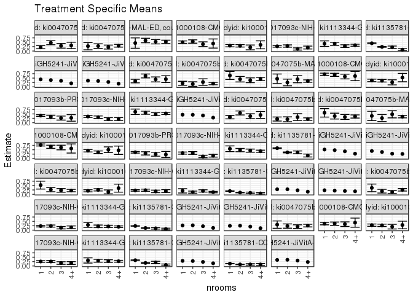

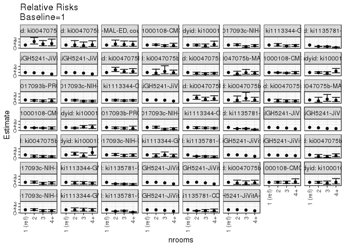

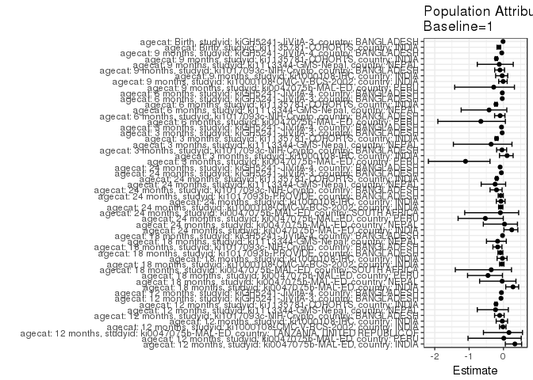

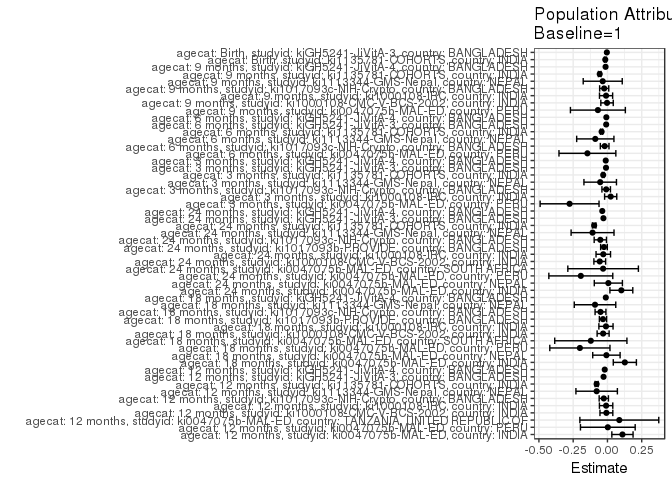

## Results Table

### Parameter: TSM

| agecat | studyid | country | intervention_level | baseline_level | estimate | ci_lower | ci_upper |
| --- | --- | --- | --- | --- | --- | --- | --- |
| Birth | ki1135781-COHORTS | INDIA | 1 | NA | 0.1344000 | 0.1224401 | 0.1463599 |
| Birth | ki1135781-COHORTS | INDIA | 2 | NA | 0.0880866 | 0.0731587 | 0.1030146 |
| Birth | ki1135781-COHORTS | INDIA | 3 | NA | 0.0898204 | 0.0464507 | 0.1331901 |
| Birth | ki1135781-COHORTS | INDIA | 4+ | NA | 0.0869565 | 0.0293732 | 0.1445398 |
| Birth | kiGH5241-JiVitA-3 | BANGLADESH | 1 | NA | 0.3457790 | NA | NA |
| Birth | kiGH5241-JiVitA-3 | BANGLADESH | 2 | NA | 0.3529638 | NA | NA |
| Birth | kiGH5241-JiVitA-3 | BANGLADESH | 3 | NA | 0.3115578 | NA | NA |
| Birth | kiGH5241-JiVitA-3 | BANGLADESH | 4+ | NA | 0.2288732 | NA | NA |
| 3 months | ki0047075b-MAL-ED | PERU | 1 | NA | 0.5263158 | 0.3013903 | 0.7512413 |
| 3 months | ki0047075b-MAL-ED | PERU | 2 | NA | 0.2692308 | 0.1484497 | 0.3900118 |
| 3 months | ki0047075b-MAL-ED | PERU | 3 | NA | 0.2258065 | 0.1215399 | 0.3300730 |
| 3 months | ki0047075b-MAL-ED | PERU | 4+ | NA | 0.2158273 | 0.1473101 | 0.2843445 |
| 3 months | ki1000108-IRC | INDIA | 1 | NA | 0.2010870 | 0.1431017 | 0.2590722 |
| 3 months | ki1000108-IRC | INDIA | 2 | NA | 0.2559524 | 0.1898815 | 0.3220233 |
| 3 months | ki1000108-IRC | INDIA | 3 | NA | 0.1388889 | 0.0257799 | 0.2519979 |
| 3 months | ki1000108-IRC | INDIA | 4+ | NA | 0.3529412 | 0.1254925 | 0.5803899 |
| 3 months | ki1017093c-NIH-Crypto | BANGLADESH | 1 | NA | 0.2234957 | 0.1797596 | 0.2672318 |
| 3 months | ki1017093c-NIH-Crypto | BANGLADESH | 2 | NA | 0.2365591 | 0.1754442 | 0.2976741 |
| 3 months | ki1017093c-NIH-Crypto | BANGLADESH | 3 | NA | 0.1666667 | 0.0942931 | 0.2390403 |
| 3 months | ki1017093c-NIH-Crypto | BANGLADESH | 4+ | NA | 0.1868132 | 0.1066777 | 0.2669487 |
| 3 months | ki1113344-GMS-Nepal | NEPAL | 1 | NA | 0.2000000 | 0.0759323 | 0.3240677 |
| 3 months | ki1113344-GMS-Nepal | NEPAL | 2 | NA | 0.1239669 | 0.0651978 | 0.1827361 |
| 3 months | ki1113344-GMS-Nepal | NEPAL | 3 | NA | 0.1928571 | 0.1274451 | 0.2582692 |
| 3 months | ki1113344-GMS-Nepal | NEPAL | 4+ | NA | 0.1259259 | 0.0863183 | 0.1655335 |
| 3 months | ki1135781-COHORTS | INDIA | 1 | NA | 0.1860535 | 0.1728289 | 0.1992781 |
| 3 months | ki1135781-COHORTS | INDIA | 2 | NA | 0.1002045 | 0.0848374 | 0.1155716 |
| 3 months | ki1135781-COHORTS | INDIA | 3 | NA | 0.0864865 | 0.0459789 | 0.1269941 |
| 3 months | ki1135781-COHORTS | INDIA | 4+ | NA | 0.0510204 | 0.0074513 | 0.0945895 |
| 3 months | kiGH5241-JiVitA-3 | BANGLADESH | 1 | NA | 0.2873291 | NA | NA |
| 3 months | kiGH5241-JiVitA-3 | BANGLADESH | 2 | NA | 0.2886870 | NA | NA |

[output cut: 186 more lines]

### Parameter: E(Y)

| agecat | studyid | country | intervention_level | baseline_level | estimate | ci_lower | ci_upper |
| --- | --- | --- | --- | --- | --- | --- | --- |
| Birth | ki1135781-COHORTS | INDIA | NA | NA | 0.1184735 | 0.1093005 | 0.1276464 |
| Birth | kiGH5241-JiVitA-3 | BANGLADESH | NA | NA | 0.3414860 | NA | NA |
| 3 months | ki0047075b-MAL-ED | PERU | NA | NA | 0.2500000 | 0.1984458 | 0.3015542 |
| 3 months | ki1000108-IRC | INDIA | NA | NA | 0.2246914 | 0.1839920 | 0.2653907 |
| 3 months | ki1017093c-NIH-Crypto | BANGLADESH | NA | NA | 0.2142857 | 0.1844587 | 0.2441127 |
| 3 months | ki1113344-GMS-Nepal | NEPAL | NA | NA | 0.1471103 | 0.1180314 | 0.1761893 |
| 3 months | ki1135781-COHORTS | INDIA | NA | NA | 0.1550128 | 0.1450565 | 0.1649691 |
| 3 months | kiGH5241-JiVitA-3 | BANGLADESH | NA | NA | 0.2768693 | NA | NA |
| 3 months | kiGH5241-JiVitA-4 | BANGLADESH | NA | NA | 0.2211111 | NA | NA |
| 6 months | ki0047075b-MAL-ED | PERU | NA | NA | 0.2222222 | 0.1725409 | 0.2719036 |
| 6 months | ki1017093c-NIH-Crypto | BANGLADESH | NA | NA | 0.2097902 | 0.1799252 | 0.2396552 |
| 6 months | ki1113344-GMS-Nepal | NEPAL | NA | NA | 0.2113677 | 0.1776128 | 0.2451225 |
| 6 months | ki1135781-COHORTS | INDIA | NA | NA | 0.1954857 | 0.1844503 | 0.2065211 |
| 6 months | kiGH5241-JiVitA-3 | BANGLADESH | NA | NA | 0.2617902 | NA | NA |
| 6 months | kiGH5241-JiVitA-4 | BANGLADESH | NA | NA | 0.2376396 | NA | NA |
| 9 months | ki0047075b-MAL-ED | PERU | NA | NA | 0.2460938 | 0.1932265 | 0.2989610 |
| 9 months | ki1000108-CMC-V-BCS-2002 | INDIA | NA | NA | 0.3688525 | 0.3193538 | 0.4183511 |
| 9 months | ki1000108-IRC | INDIA | NA | NA | 0.2740741 | 0.2305793 | 0.3175689 |
| 9 months | ki1017093c-NIH-Crypto | BANGLADESH | NA | NA | 0.2322946 | 0.2011222 | 0.2634670 |
| 9 months | ki1113344-GMS-Nepal | NEPAL | NA | NA | 0.2813067 | 0.2437292 | 0.3188843 |
| 9 months | ki1135781-COHORTS | INDIA | NA | NA | 0.2729998 | 0.2597395 | 0.2862600 |
| 9 months | kiGH5241-JiVitA-4 | BANGLADESH | NA | NA | 0.2765625 | NA | NA |
| 12 months | ki0047075b-MAL-ED | INDIA | NA | NA | 0.3289474 | 0.2678283 | 0.3900664 |
| 12 months | ki0047075b-MAL-ED | PERU | NA | NA | 0.2804878 | 0.2242354 | 0.3367402 |
| 12 months | ki0047075b-MAL-ED | TANZANIA, UNITED REPUBLIC OF | NA | NA | 0.5411255 | 0.4767264 | 0.6055247 |
| 12 months | ki1000108-CMC-V-BCS-2002 | INDIA | NA | NA | 0.4972826 | 0.4461287 | 0.5484365 |
| 12 months | ki1000108-IRC | INDIA | NA | NA | 0.2945545 | 0.2500493 | 0.3390596 |
| 12 months | ki1017093c-NIH-Crypto | BANGLADESH | NA | NA | 0.2422096 | 0.2105851 | 0.2738341 |
| 12 months | ki1113344-GMS-Nepal | NEPAL | NA | NA | 0.3422939 | 0.3028903 | 0.3816975 |
| 12 months | ki1135781-COHORTS | INDIA | NA | NA | 0.3631905 | 0.3480446 | 0.3783364 |
| 12 months | kiGH5241-JiVitA-3 | BANGLADESH | NA | NA | 0.3964727 | NA | NA |
| 12 months | kiGH5241-JiVitA-4 | BANGLADESH | NA | NA | 0.3338558 | NA | NA |
| 18 months | ki0047075b-MAL-ED | INDIA | NA | NA | 0.4561404 | 0.3913474 | 0.5209333 |
| 18 months | ki0047075b-MAL-ED | NEPAL | NA | NA | 0.1965066 | 0.1449290 | 0.2480841 |
| 18 months | ki0047075b-MAL-ED | PERU | NA | NA | 0.4459459 | 0.3804116 | 0.5114803 |
| 18 months | ki0047075b-MAL-ED | SOUTH AFRICA | NA | NA | 0.3402490 | 0.2803070 | 0.4001909 |
| 18 months | ki1000108-CMC-V-BCS-2002 | INDIA | NA | NA | 0.6883469 | 0.6410248 | 0.7356689 |
| 18 months | ki1000108-IRC | INDIA | NA | NA | 0.3573201 | 0.3104753 | 0.4041649 |
| 18 months | ki1017093b-PROVIDE | BANGLADESH | NA | NA | 0.3731884 | 0.3328048 | 0.4135720 |
| 18 months | ki1017093c-NIH-Crypto | BANGLADESH | NA | NA | 0.3012618 | 0.2655201 | 0.3370036 |
| 18 months | ki1113344-GMS-Nepal | NEPAL | NA | NA | 0.5309091 | 0.4891645 | 0.5726537 |
| 18 months | kiGH5241-JiVitA-4 | BANGLADESH | NA | NA | 0.4419171 | NA | NA |
| 24 months | ki0047075b-MAL-ED | INDIA | NA | NA | 0.4185022 | 0.3541865 | 0.4828179 |
| 24 months | ki0047075b-MAL-ED | NEPAL | NA | NA | 0.2149123 | 0.1614774 | 0.2683472 |
| 24 months | ki0047075b-MAL-ED | PERU | NA | NA | 0.3681592 | 0.3013164 | 0.4350020 |
| 24 months | ki0047075b-MAL-ED | SOUTH AFRICA | NA | NA | 0.3529412 | 0.2921001 | 0.4137823 |
| 24 months | ki1000108-CMC-V-BCS-2002 | INDIA | NA | NA | 0.7150538 | 0.6691221 | 0.7609854 |
| 24 months | ki1000108-IRC | INDIA | NA | NA | 0.4152334 | 0.3673018 | 0.4631651 |
| 24 months | ki1017093b-PROVIDE | BANGLADESH | NA | NA | 0.3292894 | 0.2909105 | 0.3676684 |
| 24 months | ki1017093c-NIH-Crypto | BANGLADESH | NA | NA | 0.2568093 | 0.2190047 | 0.2946140 |
| 24 months | ki1113344-GMS-Nepal | NEPAL | NA | NA | 0.4468938 | 0.4032281 | 0.4905594 |
| 24 months | ki1135781-COHORTS | INDIA | NA | NA | 0.4934649 | 0.4774590 | 0.5094709 |
| 24 months | kiGH5241-JiVitA-3 | BANGLADESH | NA | NA | 0.4818012 | NA | NA |
| 24 months | kiGH5241-JiVitA-4 | BANGLADESH | NA | NA | 0.3904000 | NA | NA |

### Parameter: RR

| agecat | studyid | country | intervention_level | baseline_level | estimate | ci_lower | ci_upper |
| --- | --- | --- | --- | --- | --- | --- | --- |
| Birth | ki1135781-COHORTS | INDIA | 1 | 1 | 1.0000000 | 1.0000000 | 1.0000000 |
| Birth | ki1135781-COHORTS | INDIA | 2 | 1 | 0.6554066 | 0.5412298 | 0.7936699 |
| Birth | ki1135781-COHORTS | INDIA | 3 | 1 | 0.6683062 | 0.4090207 | 1.0919576 |
| Birth | ki1135781-COHORTS | INDIA | 4+ | 1 | 0.6469979 | 0.3316841 | 1.2620634 |
| Birth | kiGH5241-JiVitA-3 | BANGLADESH | 1 | 1 | 1.0000000 | NA | NA |
| Birth | kiGH5241-JiVitA-3 | BANGLADESH | 2 | 1 | 1.0207788 | NA | NA |
| Birth | kiGH5241-JiVitA-3 | BANGLADESH | 3 | 1 | 0.9010317 | NA | NA |
| Birth | kiGH5241-JiVitA-3 | BANGLADESH | 4+ | 1 | 0.6619062 | NA | NA |
| 3 months | ki0047075b-MAL-ED | PERU | 1 | 1 | 1.0000000 | 1.0000000 | 1.0000000 |
| 3 months | ki0047075b-MAL-ED | PERU | 2 | 1 | 0.5115385 | 0.2752923 | 0.9505227 |
| 3 months | ki0047075b-MAL-ED | PERU | 3 | 1 | 0.4290323 | 0.2286897 | 0.8048841 |
| 3 months | ki0047075b-MAL-ED | PERU | 4+ | 1 | 0.4100719 | 0.2407990 | 0.6983377 |
| 3 months | ki1000108-IRC | INDIA | 1 | 1 | 1.0000000 | 1.0000000 | 1.0000000 |
| 3 months | ki1000108-IRC | INDIA | 2 | 1 | 1.2728443 | 0.8643582 | 1.8743762 |
| 3 months | ki1000108-IRC | INDIA | 3 | 1 | 0.6906907 | 0.2911280 | 1.6386386 |
| 3 months | ki1000108-IRC | INDIA | 4+ | 1 | 1.7551669 | 0.8663668 | 3.5557816 |
| 3 months | ki1017093c-NIH-Crypto | BANGLADESH | 1 | 1 | 1.0000000 | 1.0000000 | 1.0000000 |
| 3 months | ki1017093c-NIH-Crypto | BANGLADESH | 2 | 1 | 1.0584505 | 0.7654495 | 1.4636073 |
| 3 months | ki1017093c-NIH-Crypto | BANGLADESH | 3 | 1 | 0.7457265 | 0.4631541 | 1.2006976 |
| 3 months | ki1017093c-NIH-Crypto | BANGLADESH | 4+ | 1 | 0.8358693 | 0.5216427 | 1.3393792 |
| 3 months | ki1113344-GMS-Nepal | NEPAL | 1 | 1 | 1.0000000 | 1.0000000 | 1.0000000 |
| 3 months | ki1113344-GMS-Nepal | NEPAL | 2 | 1 | 0.6198347 | 0.2839243 | 1.3531602 |
| 3 months | ki1113344-GMS-Nepal | NEPAL | 3 | 1 | 0.9642857 | 0.4755067 | 1.9554867 |
| 3 months | ki1113344-GMS-Nepal | NEPAL | 4+ | 1 | 0.6296296 | 0.3140684 | 1.2622521 |
| 3 months | ki1135781-COHORTS | INDIA | 1 | 1 | 1.0000000 | 1.0000000 | 1.0000000 |
| 3 months | ki1135781-COHORTS | INDIA | 2 | 1 | 0.5385789 | 0.4548217 | 0.6377605 |
| 3 months | ki1135781-COHORTS | INDIA | 3 | 1 | 0.4648474 | 0.2894484 | 0.7465340 |
| 3 months | ki1135781-COHORTS | INDIA | 4+ | 1 | 0.2742244 | 0.1164009 | 0.6460348 |
| 3 months | kiGH5241-JiVitA-3 | BANGLADESH | 1 | 1 | 1.0000000 | NA | NA |
| 3 months | kiGH5241-JiVitA-3 | BANGLADESH | 2 | 1 | 1.0047261 | NA | NA |

[output cut: 186 more lines]

### Parameter: PAR

| agecat | studyid | country | intervention_level | baseline_level | estimate | ci_lower | ci_upper |
| --- | --- | --- | --- | --- | --- | --- | --- |
| Birth | ki1135781-COHORTS | INDIA | 1 | NA | -0.0159265 | -0.0222291 | -0.0096240 |
| Birth | kiGH5241-JiVitA-3 | BANGLADESH | 1 | NA | -0.0042930 | NA | NA |
| 3 months | ki0047075b-MAL-ED | PERU | 1 | NA | -0.2763158 | -0.4912144 | -0.0614172 |
| 3 months | ki1000108-IRC | INDIA | 1 | NA | 0.0236044 | -0.0207083 | 0.0679171 |
| 3 months | ki1017093c-NIH-Crypto | BANGLADESH | 1 | NA | -0.0092100 | -0.0403304 | 0.0219104 |
| 3 months | ki1113344-GMS-Nepal | NEPAL | 1 | NA | -0.0528897 | -0.1715563 | 0.0657770 |
| 3 months | ki1135781-COHORTS | INDIA | 1 | NA | -0.0310407 | -0.0377343 | -0.0243471 |
| 3 months | kiGH5241-JiVitA-3 | BANGLADESH | 1 | NA | -0.0104598 | NA | NA |
| 3 months | kiGH5241-JiVitA-4 | BANGLADESH | 1 | NA | -0.0125845 | NA | NA |
| 6 months | ki0047075b-MAL-ED | PERU | 1 | NA | -0.1461988 | -0.3536656 | 0.0612680 |
| 6 months | ki1017093c-NIH-Crypto | BANGLADESH | 1 | NA | -0.0202983 | -0.0518569 | 0.0112603 |
| 6 months | ki1113344-GMS-Nepal | NEPAL | 1 | NA | -0.0886323 | -0.2245444 | 0.0472798 |
| 6 months | ki1135781-COHORTS | INDIA | 1 | NA | -0.0426095 | -0.0502106 | -0.0350085 |
| 6 months | kiGH5241-JiVitA-3 | BANGLADESH | 1 | NA | -0.0092658 | NA | NA |
| 6 months | kiGH5241-JiVitA-4 | BANGLADESH | 1 | NA | -0.0080672 | NA | NA |
| 9 months | ki0047075b-MAL-ED | PERU | 1 | NA | -0.0696957 | -0.2700483 | 0.1306568 |
| 9 months | ki1000108-CMC-V-BCS-2002 | INDIA | 1 | NA | -0.0030068 | -0.0483368 | 0.0423232 |
| 9 months | ki1000108-IRC | INDIA | 1 | NA | -0.0100789 | -0.0580789 | 0.0379210 |
| 9 months | ki1017093c-NIH-Crypto | BANGLADESH | 1 | NA | -0.0237295 | -0.0569412 | 0.0094822 |
| 9 months | ki1113344-GMS-Nepal | NEPAL | 1 | NA | -0.0344828 | -0.1768764 | 0.1079109 |
| 9 months | ki1135781-COHORTS | INDIA | 1 | NA | -0.0563951 | -0.0657930 | -0.0469973 |
| 9 months | kiGH5241-JiVitA-4 | BANGLADESH | 1 | NA | -0.0137601 | NA | NA |
| 12 months | ki0047075b-MAL-ED | INDIA | 1 | NA | 0.1094352 | 0.0319857 | 0.1868846 |
| 12 months | ki0047075b-MAL-ED | PERU | 1 | NA | 0.0027100 | -0.1969461 | 0.2023662 |
| 12 months | ki0047075b-MAL-ED | TANZANIA, UNITED REPUBLIC OF | 1 | NA | 0.0865801 | -0.2012151 | 0.3743753 |
| 12 months | ki1000108-CMC-V-BCS-2002 | INDIA | 1 | NA | -0.0077174 | -0.0546010 | 0.0391662 |
| 12 months | ki1000108-IRC | INDIA | 1 | NA | -0.0097934 | -0.0585331 | 0.0389464 |
| 12 months | ki1017093c-NIH-Crypto | BANGLADESH | 1 | NA | -0.0266725 | -0.0604734 | 0.0071283 |
| 12 months | ki1113344-GMS-Nepal | NEPAL | 1 | NA | -0.0787587 | -0.2300108 | 0.0724934 |
| 12 months | ki1135781-COHORTS | INDIA | 1 | NA | -0.0790780 | -0.0903378 | -0.0678181 |
| 12 months | kiGH5241-JiVitA-3 | BANGLADESH | 1 | NA | -0.0284357 | NA | NA |
| 12 months | kiGH5241-JiVitA-4 | BANGLADESH | 1 | NA | -0.0198503 | NA | NA |
| 18 months | ki0047075b-MAL-ED | INDIA | 1 | NA | 0.1268721 | 0.0425209 | 0.2112232 |
| 18 months | ki0047075b-MAL-ED | NEPAL | 1 | NA | -0.0075751 | -0.1074592 | 0.0923090 |
| 18 months | ki0047075b-MAL-ED | PERU | 1 | NA | -0.2011129 | -0.4206446 | 0.0184189 |
| 18 months | ki0047075b-MAL-ED | SOUTH AFRICA | 1 | NA | -0.1212895 | -0.3846911 | 0.1421121 |
| 18 months | ki1000108-CMC-V-BCS-2002 | INDIA | 1 | NA | -0.0316531 | -0.0753931 | 0.0120869 |
| 18 months | ki1000108-IRC | INDIA | 1 | NA | -0.0108118 | -0.0624910 | 0.0408675 |
| 18 months | ki1017093b-PROVIDE | BANGLADESH | 1 | NA | -0.0325708 | -0.0589887 | -0.0061528 |
| 18 months | ki1017093c-NIH-Crypto | BANGLADESH | 1 | NA | -0.0506545 | -0.0902377 | -0.0110714 |
| 18 months | ki1113344-GMS-Nepal | NEPAL | 1 | NA | -0.0907125 | -0.2420914 | 0.0606664 |
| 18 months | kiGH5241-JiVitA-4 | BANGLADESH | 1 | NA | -0.0120124 | NA | NA |
| 24 months | ki0047075b-MAL-ED | INDIA | 1 | NA | 0.1014290 | 0.0179766 | 0.1848814 |
| 24 months | ki0047075b-MAL-ED | NEPAL | 1 | NA | 0.0065789 | -0.0960405 | 0.1091984 |
| 24 months | ki0047075b-MAL-ED | PERU | 1 | NA | -0.1943408 | -0.4275676 | 0.0388860 |
| 24 months | ki0047075b-MAL-ED | SOUTH AFRICA | 1 | NA | -0.0316742 | -0.2890923 | 0.2257439 |
| 24 months | ki1000108-CMC-V-BCS-2002 | INDIA | 1 | NA | -0.0560905 | -0.0989505 | -0.0132305 |
| 24 months | ki1000108-IRC | INDIA | 1 | NA | -0.0304188 | -0.0832666 | 0.0224290 |
| 24 months | ki1017093b-PROVIDE | BANGLADESH | 1 | NA | -0.0253904 | -0.0496680 | -0.0011127 |
| 24 months | ki1017093c-NIH-Crypto | BANGLADESH | 1 | NA | -0.0519464 | -0.0968728 | -0.0070200 |
| 24 months | ki1113344-GMS-Nepal | NEPAL | 1 | NA | -0.1086618 | -0.2651794 | 0.0478559 |
| 24 months | ki1135781-COHORTS | INDIA | 1 | NA | -0.0968913 | -0.1097026 | -0.0840800 |
| 24 months | kiGH5241-JiVitA-3 | BANGLADESH | 1 | NA | -0.0293369 | NA | NA |
| 24 months | kiGH5241-JiVitA-4 | BANGLADESH | 1 | NA | -0.0377879 | NA | NA |

### Parameter: PAF

| agecat | studyid | country | intervention_level | baseline_level | estimate | ci_lower | ci_upper |
| --- | --- | --- | --- | --- | --- | --- | --- |
| Birth | ki1135781-COHORTS | INDIA | 1 | NA | -0.1344312 | -0.1881499 | -0.0831412 |
| Birth | kiGH5241-JiVitA-3 | BANGLADESH | 1 | NA | -0.0125715 | NA | NA |
| 3 months | ki0047075b-MAL-ED | PERU | 1 | NA | -1.1052632 | -2.1851486 | -0.3914996 |
| 3 months | ki1000108-IRC | INDIA | 1 | NA | 0.1050526 | -0.1150299 | 0.2816955 |
| 3 months | ki1017093c-NIH-Crypto | BANGLADESH | 1 | NA | -0.0429799 | -0.1987444 | 0.0925445 |
| 3 months | ki1113344-GMS-Nepal | NEPAL | 1 | NA | -0.3595238 | -1.4577436 | 0.2479667 |
| 3 months | ki1135781-COHORTS | INDIA | 1 | NA | -0.2002460 | -0.2430880 | -0.1588806 |
| 3 months | kiGH5241-JiVitA-3 | BANGLADESH | 1 | NA | -0.0377788 | NA | NA |
| 3 months | kiGH5241-JiVitA-4 | BANGLADESH | 1 | NA | -0.0569150 | NA | NA |
| 6 months | ki0047075b-MAL-ED | PERU | 1 | NA | -0.6578947 | -1.9104416 | 0.0556021 |
| 6 months | ki1017093c-NIH-Crypto | BANGLADESH | 1 | NA | -0.0967552 | -0.2576867 | 0.0435838 |
| 6 months | ki1113344-GMS-Nepal | NEPAL | 1 | NA | -0.4193277 | -1.2314143 | 0.0972133 |
| 6 months | ki1135781-COHORTS | INDIA | 1 | NA | -0.2179676 | -0.2566491 | -0.1804767 |
| 6 months | kiGH5241-JiVitA-3 | BANGLADESH | 1 | NA | -0.0353941 | NA | NA |
| 6 months | kiGH5241-JiVitA-4 | BANGLADESH | 1 | NA | -0.0339471 | NA | NA |
| 9 months | ki0047075b-MAL-ED | PERU | 1 | NA | -0.2832080 | -1.4194141 | 0.3194126 |
| 9 months | ki1000108-CMC-V-BCS-2002 | INDIA | 1 | NA | -0.0081519 | -0.1388519 | 0.1075484 |
| 9 months | ki1000108-IRC | INDIA | 1 | NA | -0.0367745 | -0.2275458 | 0.1243493 |
| 9 months | ki1017093c-NIH-Crypto | BANGLADESH | 1 | NA | -0.1021525 | -0.2545631 | 0.0317425 |
| 9 months | ki1113344-GMS-Nepal | NEPAL | 1 | NA | -0.1225806 | -0.7621150 | 0.2848439 |
| 9 months | ki1135781-COHORTS | INDIA | 1 | NA | -0.2065758 | -0.2413545 | -0.1727715 |
| 9 months | kiGH5241-JiVitA-4 | BANGLADESH | 1 | NA | -0.0497540 | NA | NA |
| 12 months | ki0047075b-MAL-ED | INDIA | 1 | NA | 0.3326829 | 0.0543609 | 0.5290887 |
| 12 months | ki0047075b-MAL-ED | PERU | 1 | NA | 0.0096618 | -1.0320653 | 0.5173533 |
| 12 months | ki0047075b-MAL-ED | TANZANIA, UNITED REPUBLIC OF | 1 | NA | 0.1600000 | -0.5827978 | 0.5542071 |
| 12 months | ki1000108-CMC-V-BCS-2002 | INDIA | 1 | NA | -0.0155191 | -0.1143288 | 0.0745289 |
| 12 months | ki1000108-IRC | INDIA | 1 | NA | -0.0332481 | -0.2126912 | 0.1196427 |
| 12 months | ki1017093c-NIH-Crypto | BANGLADESH | 1 | NA | -0.1101217 | -0.2585808 | 0.0208255 |
| 12 months | ki1113344-GMS-Nepal | NEPAL | 1 | NA | -0.2300909 | -0.7620761 | 0.1412836 |
| 12 months | ki1135781-COHORTS | INDIA | 1 | NA | -0.2177314 | -0.2496584 | -0.1866200 |
| 12 months | kiGH5241-JiVitA-3 | BANGLADESH | 1 | NA | -0.0717217 | NA | NA |
| 12 months | kiGH5241-JiVitA-4 | BANGLADESH | 1 | NA | -0.0594577 | NA | NA |
| 18 months | ki0047075b-MAL-ED | INDIA | 1 | NA | 0.2781426 | 0.0662253 | 0.4419659 |
| 18 months | ki0047075b-MAL-ED | NEPAL | 1 | NA | -0.0385488 | -0.6941967 | 0.3633658 |
| 18 months | ki0047075b-MAL-ED | PERU | 1 | NA | -0.4509804 | -1.0454095 | -0.0293020 |
| 18 months | ki0047075b-MAL-ED | SOUTH AFRICA | 1 | NA | -0.3564728 | -1.4020928 | 0.2339936 |
| 18 months | ki1000108-CMC-V-BCS-2002 | INDIA | 1 | NA | -0.0459843 | -0.1117995 | 0.0159349 |
| 18 months | ki1000108-IRC | INDIA | 1 | NA | -0.0302579 | -0.1855412 | 0.1046862 |
| 18 months | ki1017093b-PROVIDE | BANGLADESH | 1 | NA | -0.0872770 | -0.1606199 | -0.0185688 |
| 18 months | ki1017093c-NIH-Crypto | BANGLADESH | 1 | NA | -0.1681413 | -0.3072193 | -0.0438601 |
| 18 months | ki1113344-GMS-Nepal | NEPAL | 1 | NA | -0.1708626 | -0.4943765 | 0.0826145 |
| 18 months | kiGH5241-JiVitA-4 | BANGLADESH | 1 | NA | -0.0271825 | NA | NA |
| 24 months | ki0047075b-MAL-ED | INDIA | 1 | NA | 0.2423620 | 0.0138415 | 0.4179279 |
| 24 months | ki0047075b-MAL-ED | NEPAL | 1 | NA | 0.0306122 | -0.5863776 | 0.4076362 |
| 24 months | ki0047075b-MAL-ED | PERU | 1 | NA | -0.5278716 | -1.3214412 | -0.0055786 |
| 24 months | ki0047075b-MAL-ED | SOUTH AFRICA | 1 | NA | -0.0897436 | -1.1281603 | 0.4419870 |
| 24 months | ki1000108-CMC-V-BCS-2002 | INDIA | 1 | NA | -0.0784424 | -0.1410597 | -0.0192613 |
| 24 months | ki1000108-IRC | INDIA | 1 | NA | -0.0732570 | -0.2085489 | 0.0468895 |
| 24 months | ki1017093b-PROVIDE | BANGLADESH | 1 | NA | -0.0771066 | -0.1534495 | -0.0058165 |
| 24 months | ki1017093c-NIH-Crypto | BANGLADESH | 1 | NA | -0.2022762 | -0.3900887 | -0.0398387 |
| 24 months | ki1113344-GMS-Nepal | NEPAL | 1 | NA | -0.2431490 | -0.6487751 | 0.0626863 |
| 24 months | ki1135781-COHORTS | INDIA | 1 | NA | -0.1963489 | -0.2236370 | -0.1696693 |
| 24 months | kiGH5241-JiVitA-3 | BANGLADESH | 1 | NA | -0.0608900 | NA | NA |
| 24 months | kiGH5241-JiVitA-4 | BANGLADESH | 1 | NA | -0.0967928 | NA | NA |